# expectation and variance

[This is how exercises are highlighted]

[This is how your answers are highlighted]

## Numerical integration

To perform numerical integration of a one-dimensional function, we can use the `integrate` function.

For example, we can compute $\int_{2}^5 x^2 + \cos(x) dx$ as follows

```r
f <- function(x) {
   return(x ^ 2 + cos(x))
}
integrate(f, lower = 2, upper = 5)
```

```
## 37.13178 with absolute error < 4.1e-13
```

The function `integrate` accepts the following parameters:

- `f` the function to integrate, must accept a numerical vector and return a numerical vector of the same length;
- `lower` and `upper` are the lower and upper limits of integration, respectively, they can be `-Inf` or `Inf`
- there are further optional parameters, cf. `?integrate`

It is a requirement that the function `f` accepts a numerical vector and returns a numerical vector of the same length. For example, the following fails

```r
f <- function() {
   return(1)
}
integrate(f, lower  = 0, upper = 1)
```

```
## Error in f(x, ...): unused argument (x)
```

1. Describe the problem in above code chunk.

`integrate` expects a function as first argument that takes a vector as input and outputs a vector of function evaluations. In above code chunk, the function `f` does not accept any argument.

Also, the following fails because the function `f` does not return a vector

```r
f <- function(x) {
   return(1)
}
integrate(f, lower  = 0, upper = 1)
```

```
## Error in integrate(f, lower = 0, upper = 1): evaluation of function gave a result of wrong length
```

To make the example work, we can change the example as follows

```r
f <- function(x) {
   return(rep(1, length(x)))
}
integrate(f, lower  = 0, upper = 1)
```

```
## 1 with absolute error < 1.1e-14
```

Instead, we could have used the function `Vectorize` to *vectorize* the original function definition; for example

```r
g <- function(x) {
   return(1)
}

g_vect <- Vectorize(g)

integrate(g_vect, lower = 0, upper = 1)
```

```
## 1 with absolute error < 1.1e-14
```

2. Compute $\int_{-\pi}^{\pi} cos(x)sin(x)\,dx$
3. Compute $\int_{0}^{10} \min\{x, 4\}\, dx$
4. Numerically verify that the functions `dnorm`, `dgamma`, and `dexp` are probability density functions, that is, that they integrate to 1 and are non-negative. Do this for different settings of the parameters.
5. Define a new probability density function `dsin` of a random variable $X$ such that $f_X(x) \propto \sin(x)$ for $x \in (0,\pi)$ and $0$ otherwise. Visually inspect, that the function is non-negative and compute the normalization constant using `integrate`.

```r
f_2 <- function(x) {
   return(cos(x) * sin(x))
}
integrate(Vectorize(f_2), lower = -pi, upper = +pi)
```

```
## 0 with absolute error < 2.2e-14
```

```r
f_3 <- function(x) {
   return(min(x, 4))
}
integrate(Vectorize(f_3), lower = 0, upper = 10)
```

```
## 32 with absolute error < 0.0015
```

```r
verify <- function(d) {
   integral <- integrate(d, lower = -Inf, upper = +Inf)
   # absolute value of d
   d_abs <- function(x) abs(d(x))
   integral_abs <- integrate(d_abs, lower = -Inf, upper = +Inf)
   if (abs(integral$value - 1) < 1e-6 &&
       abs(integral$value - integral_abs$value) < 1e-6)
      return("ok")
   else
      return("not ok")
}

verify(dnorm)
```

```
## [1] "ok"
```

```r
verify(function(x) dnorm(x, mean = 10, sd = 10))
```

```
## [1] "ok"
```

```r
verify(function(x) dnorm(x, mean = -10, sd = .5))
```

```
## [1] "ok"
```

```r
verify(function(x) dgamma(x, shape = 1))
```

```
## [1] "ok"
```

```r
verify(function(x) dgamma(x, shape = 5))
```

```
## [1] "ok"
```

```r
verify(function(x) dexp(x))
```

```
## [1] "ok"
```

```r
verify(function(x) dexp(x, rate = 10))
```

```
## [1] "ok"
```

```r
# not a density
verify(function(x) dnorm(x)^2)
```

```
## [1] "not ok"
```

```r
dsin_raw <- function(x) {
   if (x > 0 && x < pi) {
      return(sin(x))
   } else{
      return(0)
   }
}

dsin_raw <- function(x) {
   if (x > 0 && x < pi) {
      return(sin(x))
   } else{
      return(0)
   }
}


# not ok, as it does not integrate to 1
verify(Vectorize(dsin_raw))
```

```
## [1] "not ok"
```

```r
# normalise dsin accordingly
n <- integrate(Vectorize(dsin_raw), lower = -Inf, upper = +Inf)$value
dsin <- function(x) {
   return(Vectorize(dsin_raw)(x) / n)
}
verify(dsin)
```

```
## [1] "ok"
```

## Expectations of random variables

We can use numerical integration to compute the expected value of random variables and of functions of random variables (using the *rule of the lazy statistician*).

For example, we can obtain the expected value of $X^2 + \sin(X)$ where $X \sim N(3,.5^2)$ as follows

```r
m = 3
s = 0.5
xf <- function(x) {
   return((x ^ 2 + sin(x)) * dnorm(x, mean = m, sd = s))
}
integrate(xf, lower = -Inf, upper = Inf)
```

```
## 9.374538 with absolute error < 6.5e-06
```

## Variance

We can obtain the variance of a random variable using the formula
$$\mathbb{V}(X) = \mathbb{E}(X^2) -
\mathbb{E}(X)^2$$

We can, for example, obtain the variance of a Gaussian random variable $X \sim N(3, 4^2)$ as

```r
f <- function(x) {
   return(dnorm(x, mean = 3, sd = 4))
}
xf <- function(x) {
   return(x * f(x))
}
xxf <- function(x) {
   return(x ^ 2 * f(x))
}
var_x <- integrate(xxf, lower = -Inf, upper = Inf)$value -
   integrate(xf, lower = -Inf, upper = Inf)$value ^ 2
var_x
```

```
## [1] 16
```

6. Write a generic function that takes as input the density function and returns the variance.
7. Obtain the variance of $Y= \sin(X)$ where $X \sim Beta(\mathrm{shape1} = 5,\ \mathrm{shape2} = 4)$.

```r
dvar <- function(d, trafo = function(x) x) {
    E_x_square <- integrate(function(x) trafo(x)^2 * d(x),
                            lower = -Inf,
                            upper = Inf)$value
    E_x <- integrate(function(x) trafo(x) * d(x),
                     lower = -Inf,
                     upper = Inf)$value
   return(E_x_square - E_x^2)
}

dvar(function(x) dnorm(x, sd = 1))
```

```
## [1] 1
```

```r
dvar(function(x) dnorm(x, sd = sqrt(42)))
```

```
## [1] 42
```

```r
dvar(function(x) dbeta(x, shape1 = 5, shape2 = 4),
     function(x) sin(x))
```

```
## [1] 0.01773525
```

## Empirical mean

To compute the empirical mean $\bar{x} = \frac{\sum_{i=1}^n x_i}{n}$ we use the `mean` function. It computes the arithmetic mean of a vector.

```r
x_obs <- runif(100, min = 0, max = 10)
mean(x_obs)
```

```
## [1] 5.098399
```

We can also exclude `NA` values with the `na.rm = TRUE` argument,

```r
obs <- c(13, 0.5, NA, 34, 9, NA)
mean(obs, na.rm = TRUE)
```

```
## [1] 14.125
```

8. Visually compare the empirical mean and the true mean of a Gaussian random variable for different values of the variance parameter and for an increasing number of observations (e.g. $n = 10,100,1000, 5000, 10000$).
9. Sample $n=100$ i.i.d. observations from an exponential distribution with $\lambda = 1$ (rate) and compute the empirical mean. Repeat the experiment 100 times and record the 100 computed empirical means.

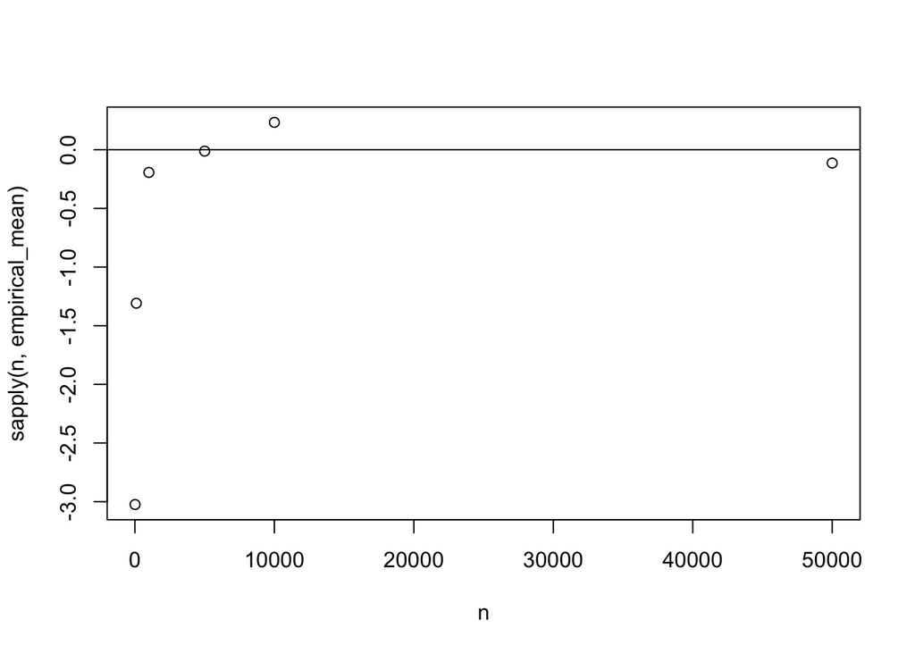

```r
compare <- function(variance) {
   empirical_mean <- function(n) mean(rnorm(n, sd = sqrt(variance)))
   n <- c(10, 100, 1000, 5000, 10000, 50000)
   plot(n, sapply(n, empirical_mean))
   abline(h = 0)
}

compare(100)
```

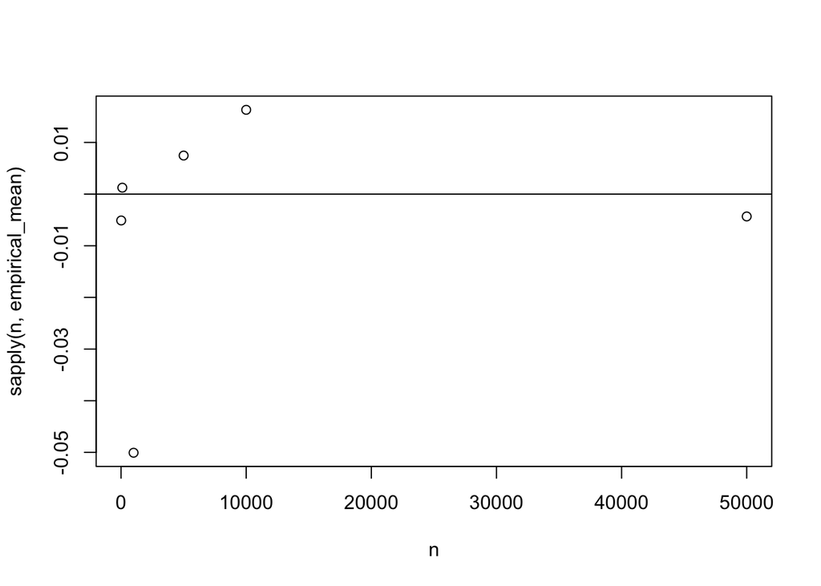

```r
compare(1)
```

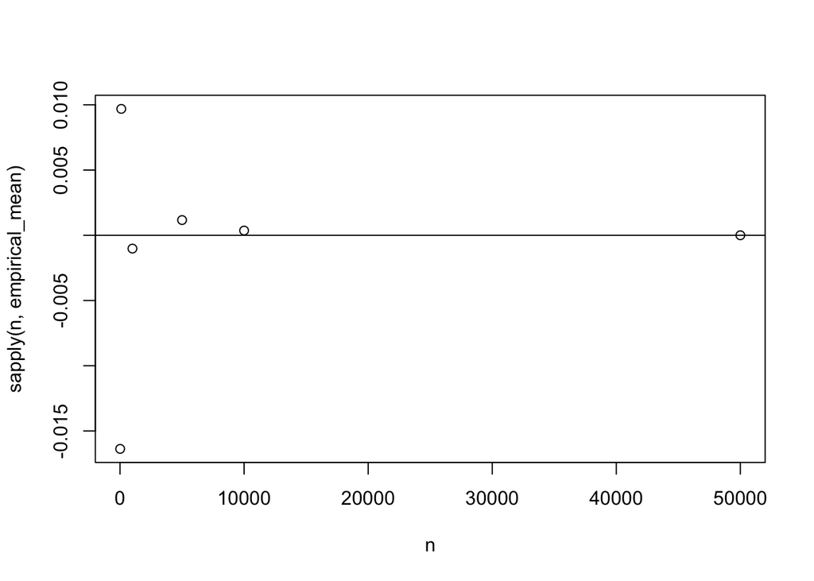

```r
compare(.01)
```

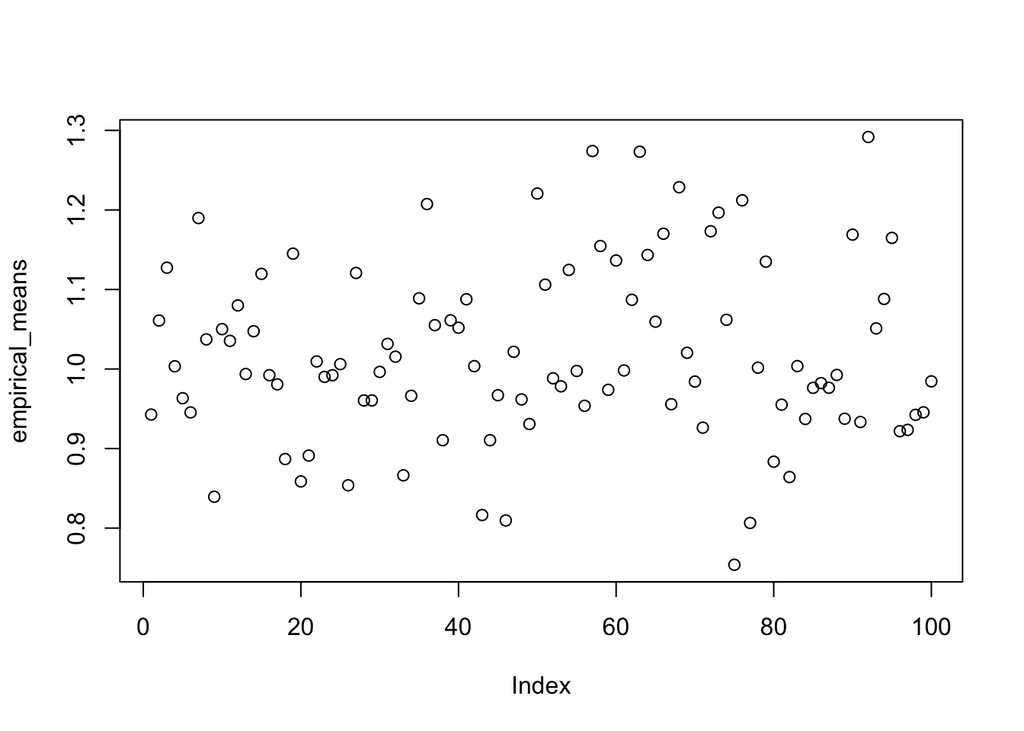

```r
# empirical mean of 100 iid obervations
empirical <- function() mean(rexp(100, rate = 1))
# repetitions
empirical_means <- replicate(100, empirical())
# observe how the empirical means fluctuate
# around the expected value of 1
plot(empirical_means)
```

## Empirical variance and standard deviation

The empirical variance $s^2 = \sum_{i=1}^n (\bar{x} - x_i)^2 / (n-1)$ can be obtained using the `var` function that takes as input a vector of observations.

```r
sample <- rnorm(100)
var(sample)
```

```
## [1] 1.051393
```

As for the `mean` function, we can exclude `NA` values,

```r
var(c(3, 2, 12, 4, NA, 54), na.rm = TRUE)
```

```
## [1] 491
```

10. Sample $100$ observations from a normal random variable $X$ and compute its empirical variance, then compute the transformed data under the scale-location transformation $Y = 2X + 1$ and obtain the empirical variance of $Y$.
11. Normalize the observations obtained in the previous exercise. Verify that the empirical mean of the normalized data is $0$ and the empirical variance of the normalized data is $1$.
12. Create a `data.frame` of $100$ observations of $100$ Gaussian random variables $X_i$  
    with means $\mu = 1$ and unit variance. For every variable $X_i$ obtain the empirical mean $\bar{X}_i$ and the empirical variance. Then, for every empirical mean $\bar{X}_i$ calculate the standard error of the mean. Compare the standard errors of the mean with the empirical standard deviation of the $100$ empirical means $\bar{X}_1, \bar{X}_2, \ldots, \bar{X}_{100}$.

```r
X_obs <- rnorm(100)
var(X_obs)
```

```
## [1] 1.105128
```

```r
Y_obs <- 2 * X_obs + 1
var(Y_obs)
```

```
## [1] 4.420513
```

```r
# alternatively, exploiting the "useful" properties
4 * var(X_obs)
```

```
## [1] 4.420513
```

```r
normalize <- function(x) {
   return((x - mean(x)) / sd(x))
}

Y_obs_normalized <- normalize(Y_obs)
mean(Y_obs_normalized)
```

```
## [1] -1.776357e-17
```

```r
var(Y_obs_normalized)
```

```
## [1] 1
```

12. `data.frame` of $100$ observations (rows), of $100$ Gaussian random variables (columns) with mean $1$

```r
df <- data.frame(
   matrix(rnorm(100 * 100, mean = 1),
          nrow = 100))
```

The empirical means and variances for each variable

```r
empirical_means <- colMeans(df)
empirical_vars <- apply(df, 2, var)
```

The standard errors of the mean for each of the 100 variables can be obtained as follows

```r
sem <- sqrt(empirical_vars / 100)
```

The standard deviation of the 100 empirical means is

```r
sd_of_means <- sd(empirical_means)
```

We compare by plotting a constant line for the `sd_of_means` and plotting sems

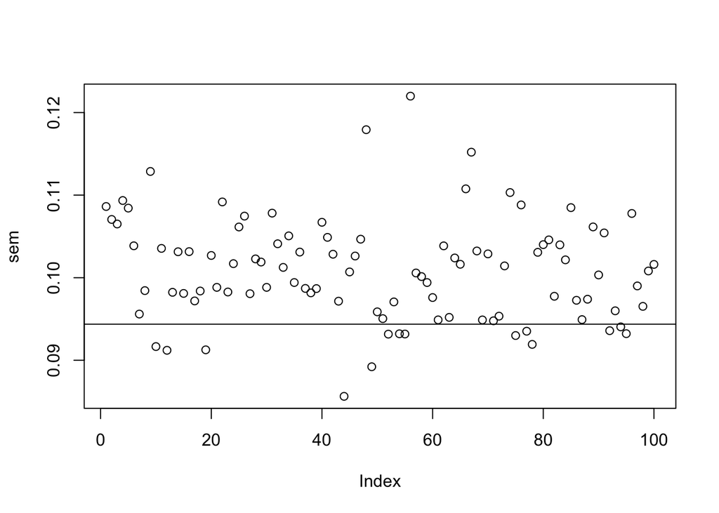

```r
plot(sem)
abline(h = sd_of_means)
```